# DDS Case Study 2 RMarkdown

Sean McWhirter

11/30/2019

Hello and thank you for providing the opportunity to provide my insight on this challenge that the company is facing. We will walk through the data set that was provided, look at some of the variables, build a classification model tha twill tell us the liklihood of an employee leaving, and finally, we will use linear regression to predict th monthly income of a set of employees.

#Upload data and take first look

```r
#File Upload
work=read.csv("C:/Users/seans/Desktop/DDS/Unit 14 and 15 Case Study 2/CaseStudy2-data.csv", header=TRUE, sep=",", stringsAsFactors = TRUE)

#File for Classification Predictions
Case2PredictionsSeanMcWhirter_Attrition=read.csv("C:/Users/seans/Desktop/DDS/Unit 14 and 15 Case Study 2/CaseStudy2CompSet No Attrition.csv", header=TRUE, sep=",", stringsAsFactors = TRUE)

#File for Linear Regression Predictions
Case2PredictionsSeanMcWhirter=read.csv("C:/Users/seans/Desktop/DDS/Unit 14 and 15 Case Study 2/CaseStudy2CompSetNoSalary.csv", header=TRUE, sep=",", stringsAsFactors = TRUE)

#Packages Used
library(tidyverse)
```

```r
library(dplyr)
library(ggplot2)
library(GGally)
library(ggthemes)
library(doBy)
library(e1071)
library(kableExtra)
library(knitr)
library(mlbench)
library(maps)
library(openintro)
library(stringr)
library(usmap)
library(ggplot2)
library(class)
library(e1071)
library(caret)
library(mlbench)
library(caret)
library(mlr)
library(gplots)
library(randomForest)
library(plyr)
library(corrplot)
library(purrr)
library(skimr)
str(work)
```

```
## 'data.frame':    870 obs. of  36 variables:
##  $ ID                      : int  1 2 3 4 5 6 7 8 9 10 ...
##  $ Age                     : int  32 40 35 32 24 27 41 37 34 34 ...
##  $ Attrition               : Factor w/ 2 levels "No","Yes": 1 1 1 1 1 1 1 1 1 1 ...
##  $ BusinessTravel          : Factor w/ 3 levels "Non-Travel","Travel_Frequently",..: 3 3 2 3 2 2 3 3 3 2 ...
##  $ DailyRate               : int  117 1308 200 801 567 294 1283 309 1333 653 ...
##  $ Department              : Factor w/ 3 levels "Human Resources",..: 3 2 2 3 2 2 2 3 3 2 ...
##  $ DistanceFromHome        : int  13 14 18 1 2 10 5 10 10 10 ...
##  $ Education               : int  4 3 2 4 1 2 5 4 4 4 ...
##  $ EducationField          : Factor w/ 6 levels "Human Resources",..: 2 4 2 3 6 2 4 2 2 6 ...
##  $ EmployeeCount           : int  1 1 1 1 1 1 1 1 1 1 ...
##  $ EmployeeNumber          : int  859 1128 1412 2016 1646 733 1448 1105 1055 1597 ...
##  $ EnvironmentSatisfaction : int  2 3 3 3 1 4 2 4 3 4 ...
##  $ Gender                  : Factor w/ 2 levels "Female","Male": 2 2 2 1 1 2 2 1 1 2 ...
##  $ HourlyRate              : int  73 44 60 48 32 32 90 88 87 92 ...
```

[output cut: 22 more lines]

```r
skim(work)
```

```
## Skim summary statistics
##  n obs: 870
##  n variables: 36
##
## -- Variable type:factor ---------------------------------------------------------------------------------------------------------------------------------
##        variable missing complete   n n_unique
##       Attrition       0      870 870        2
##  BusinessTravel       0      870 870        3
##      Department       0      870 870        3
##  EducationField       0      870 870        6
##          Gender       0      870 870        2
##         JobRole       0      870 870        9
##   MaritalStatus       0      870 870        3
##          Over18       0      870 870        1
##        OverTime       0      870 870        2
##                             top_counts ordered
##               No: 730, Yes: 140, NA: 0   FALSE
##     Tra: 618, Tra: 158, Non: 94, NA: 0   FALSE
##     Res: 562, Sal: 273, Hum: 35, NA: 0   FALSE
##  Lif: 358, Med: 270, Mar: 100, Tec: 75   FALSE
##              Mal: 516, Fem: 354, NA: 0   FALSE
##  Sal: 200, Res: 172, Lab: 153, Man: 87   FALSE
##    Mar: 410, Sin: 269, Div: 191, NA: 0   FALSE
##                          Y: 870, NA: 0   FALSE
##               No: 618, Yes: 252, NA: 0   FALSE
##
## -- Variable type:integer --------------------------------------------------------------------------------------------------------------------------------
##                  variable missing complete   n     mean      sd   p0
##                       Age       0      870 870    36.83    8.93   18
##                 DailyRate       0      870 870   815.23  401.12  103
##          DistanceFromHome       0      870 870     9.34    8.14    1
##                 Education       0      870 870     2.9     1.02    1
##             EmployeeCount       0      870 870     1       0       1
##            EmployeeNumber       0      870 870  1029.83  604.79    1
##   EnvironmentSatisfaction       0      870 870     2.7     1.1     1
##                HourlyRate       0      870 870    65.61   20.13   30
##                        ID       0      870 870   435.5   251.29    1
##            JobInvolvement       0      870 870     2.72    0.7     1
##                  JobLevel       0      870 870     2.04    1.09    1
##           JobSatisfaction       0      870 870     2.71    1.11    1
```

[output cut: 28 more lines]

```
##  2839.5   4945.5  8182    19999 ▇▇▃▂▁▁▁▁
##  8092    14074.5 20456.25 26997 ▆▇▇▇▇▆▇▆
##     1        2       4        9 ▇▂▂▂▁▁▁▁
##    12       14      18       25 ▇▇▃▃▁▂▂▁
##     3        3       3        4 ▇▁▁▁▁▁▁▂
##     2        3       4        4 ▅▁▅▁▁▇▁▇
##    80       80      80       80 ▁▁▁▇▁▁▁▁
##     0        1       1        3 ▇▁▇▁▁▂▁▁
##     6       10      15       40 ▅▇▂▂▁▁▁▁
##     2        3       3        6 ▁▁▇▇▁▂▂▁
##     2        3       3        4 ▁▁▃▁▁▇▁▂
##     3        5      10       40 ▇▅▁▁▁▁▁▁
##     2        3       7       18 ▇▂▁▅▁▁▁▁
##     0        1       3       15 ▇▂▁▁▁▁▁▁
##     2        3       7       17 ▇▂▁▃▁▁▁▁
```

```r
count(work$Attrition)
```

```
##     x freq
## 1  No  730
## 2 Yes  140
```

```r
#Check for missing values
colSums(is.na(work))
```

```
##                       ID                      Age                Attrition
##                        0                        0                        0
##           BusinessTravel                DailyRate               Department
##                        0                        0                        0
##         DistanceFromHome                Education           EducationField
##                        0                        0                        0
##            EmployeeCount           EmployeeNumber  EnvironmentSatisfaction
##                        0                        0                        0
##                   Gender               HourlyRate           JobInvolvement
##                        0                        0                        0
##                 JobLevel                  JobRole          JobSatisfaction
##                        0                        0                        0
##            MaritalStatus            MonthlyIncome              MonthlyRate
##                        0                        0                        0
##       NumCompaniesWorked                   Over18                 OverTime
##                        0                        0                        0
##        PercentSalaryHike        PerformanceRating RelationshipSatisfaction
##                        0                        0                        0
##            StandardHours         StockOptionLevel        TotalWorkingYears
##                        0                        0                        0
##    TrainingTimesLastYear          WorkLifeBalance           YearsAtCompany
##                        0                        0                        0
##       YearsInCurrentRole  YearsSinceLastPromotion     YearsWithCurrManager
##                        0                        0                        0
```

#Here is a quick way we can visualize the data that was provided. This will give us the starting point to begin our analysis. #What we are looking for are variables where attirition stands out from the non-attrition values.

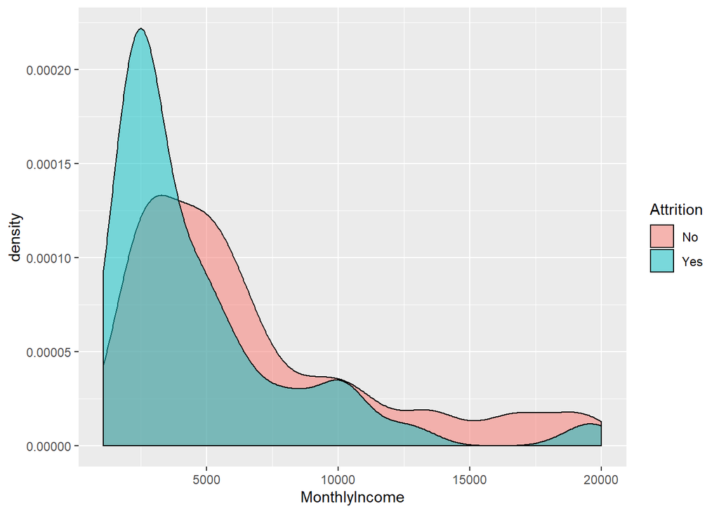

```r
#Automated EDA
# step 1, save target variable name

target <- "Attrition"
# step 2, save explanator variable names
numvars <- work %>% keep(is.numeric) %>% colnames


numplot <- function(df, explan, resp) {
  ggplot(data = df) + geom_density(aes_string(x = explan, fill = resp), alpha = 0.5)
}

numplot(work, explan = "MonthlyIncome", resp = "Attrition")
```

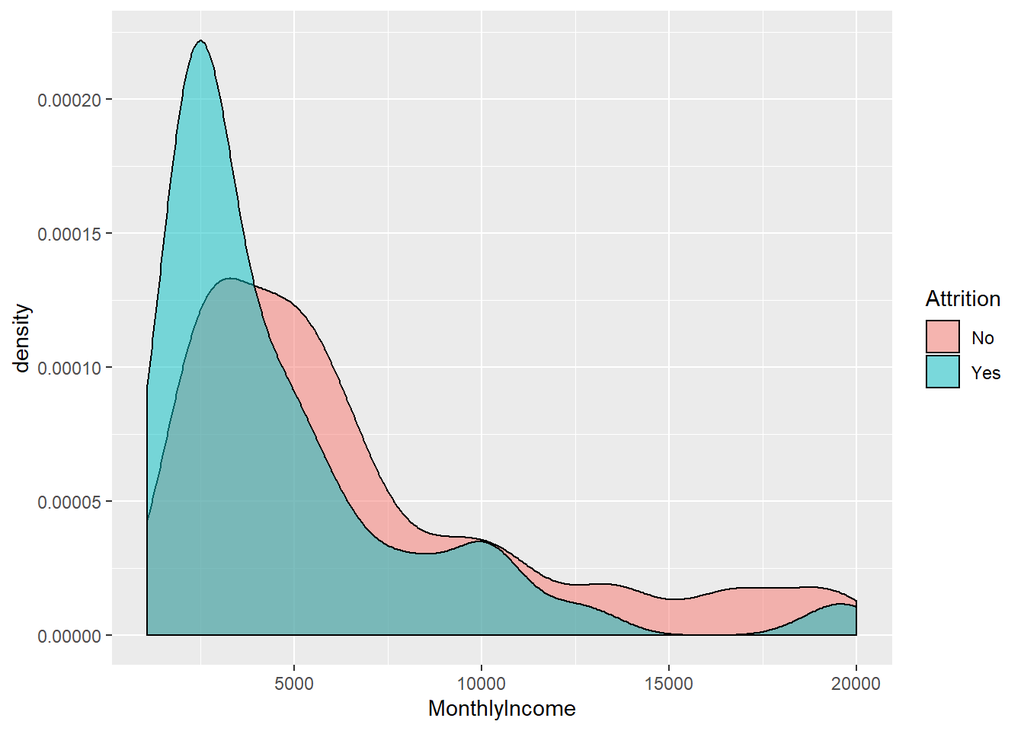

```r
numplot(work, explan = "MonthlyIncome", resp = "Attrition")
```

```r
plotlist <- lapply(numvars, function(x) numplot(work, x, "Attrition"))


png()
lapply(numvars, function(x) numplot(work, x, "Attrition"))
```

```r
dev.off()
```

[figure not shown]

```r
library(cowplot)
plot_grid(plotlist = plotlist)
```

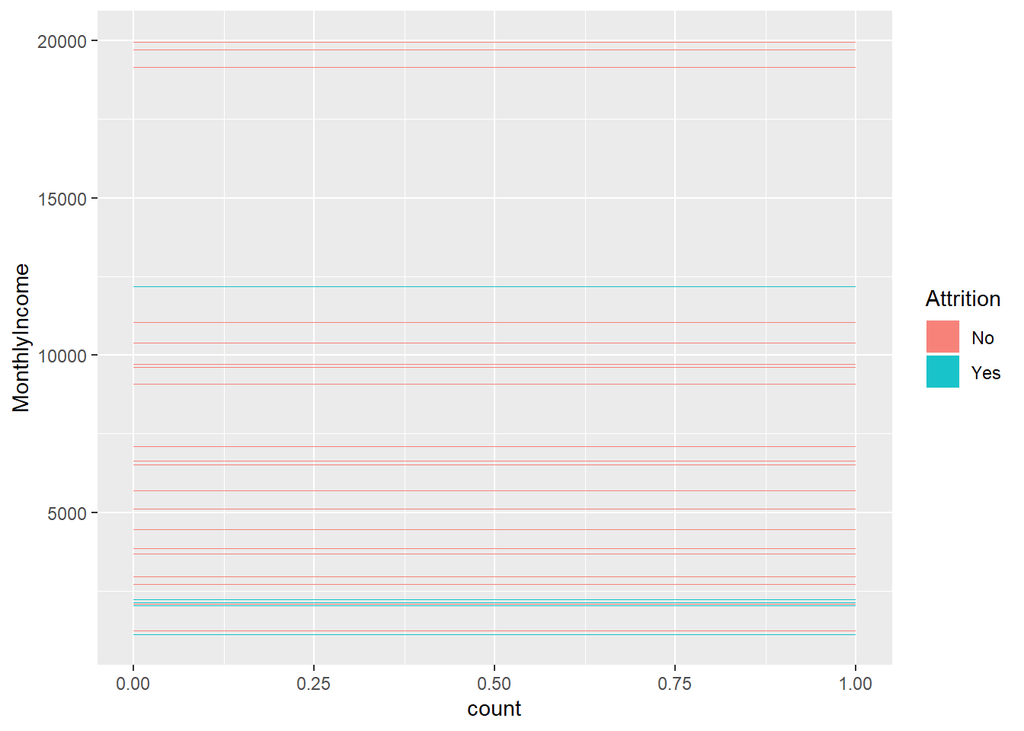

```r
# categorical vs categorical
ggplot(data = work) + geom_bar(aes(x = MonthlyIncome, fill = Attrition), position = "fill", alpha = 0.9) + coord_flip()
```

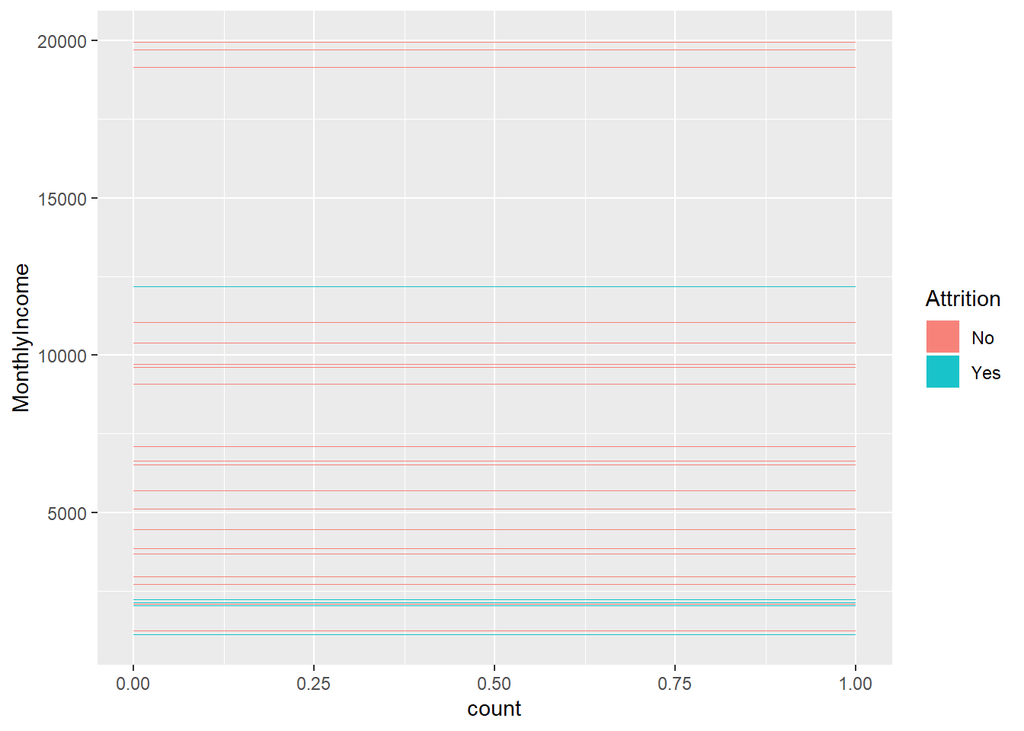

```r
ones <- rep(1, nrow(work))
zeroes <- rep(0, nrow(work))
onezeroes <- c(ones, zeroes)

work$rcat <- sample(onezeroes, nrow(work))


ggplot(data = work) + geom_bar(aes(x = MonthlyIncome, fill = Attrition), position = "fill", alpha = 0.9) + coord_flip()
```

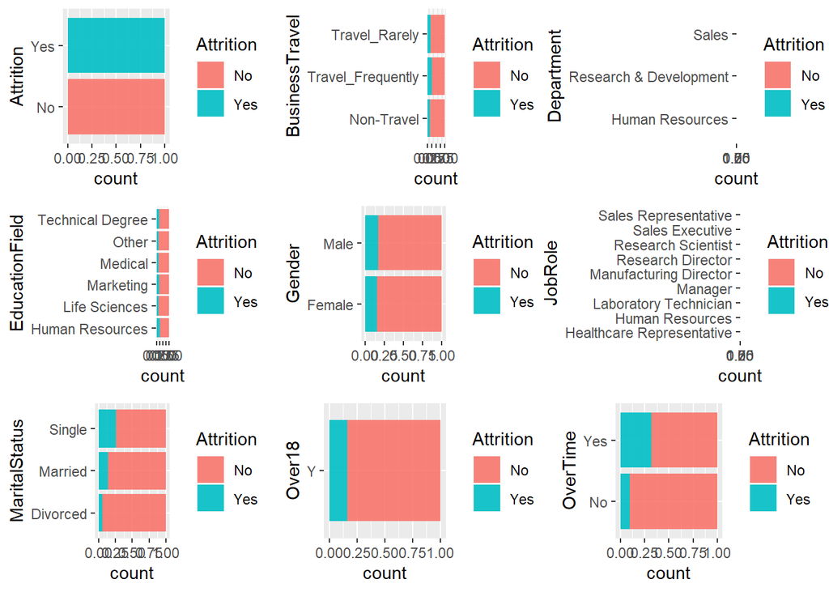

```r
# step 1: Name target variable:

target <- "Attrition"

# step 2: name explanatory vars

expls <- work %>% keep(is.factor) %>% colnames


catplot <- function(df, x,y){
  ggplot(data = df, aes_string(x = x, fill = y)) +
    geom_bar(position = "fill", alpha = 0.9) +
    coord_flip()
}


plotlist2 <- lapply(expls, function(x) catplot(work, x, target))
plot_grid(plotlist = plotlist2)
```

#Additional EDA - Scatter Plots #Here we are trying to see if we can gain any further insights into how these variables interact with attrition.

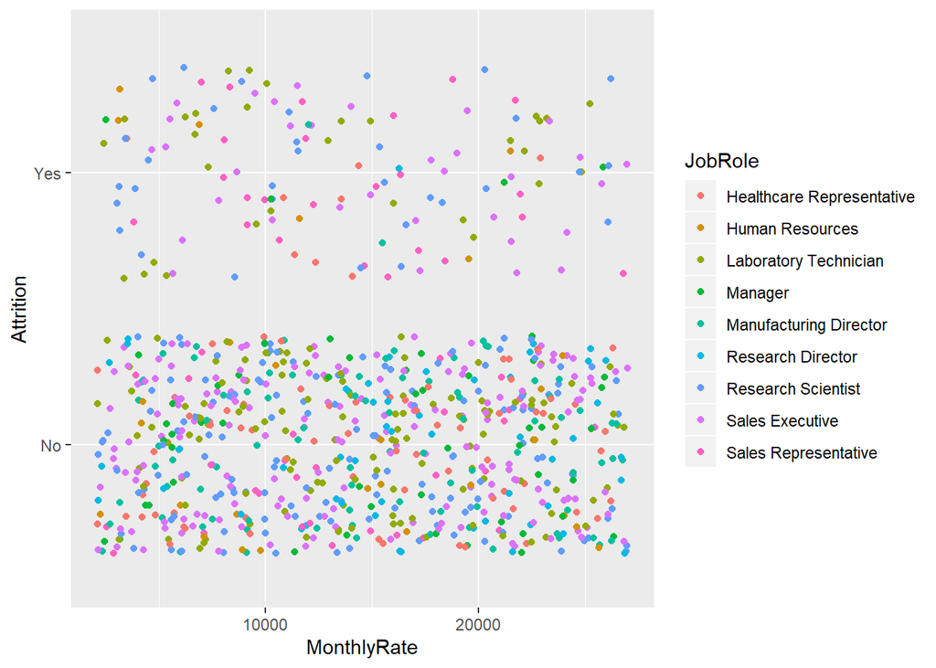

```r
#Plots to see what is correlated with Attrition)
ggplot(work, aes(x=MonthlyRate, y=Attrition,color=JobRole))+geom_point(position="jitter")
```

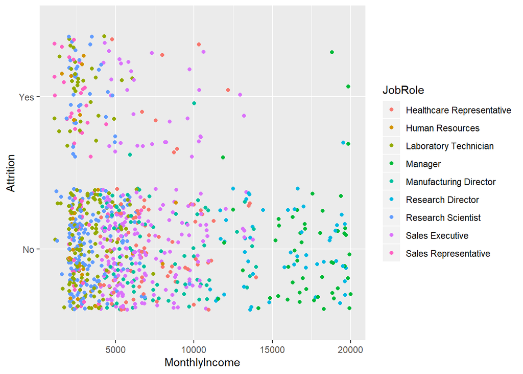

```r
ggplot(work, aes(x=MonthlyIncome, y=Attrition,color=JobRole))+geom_point(position="jitter")
```

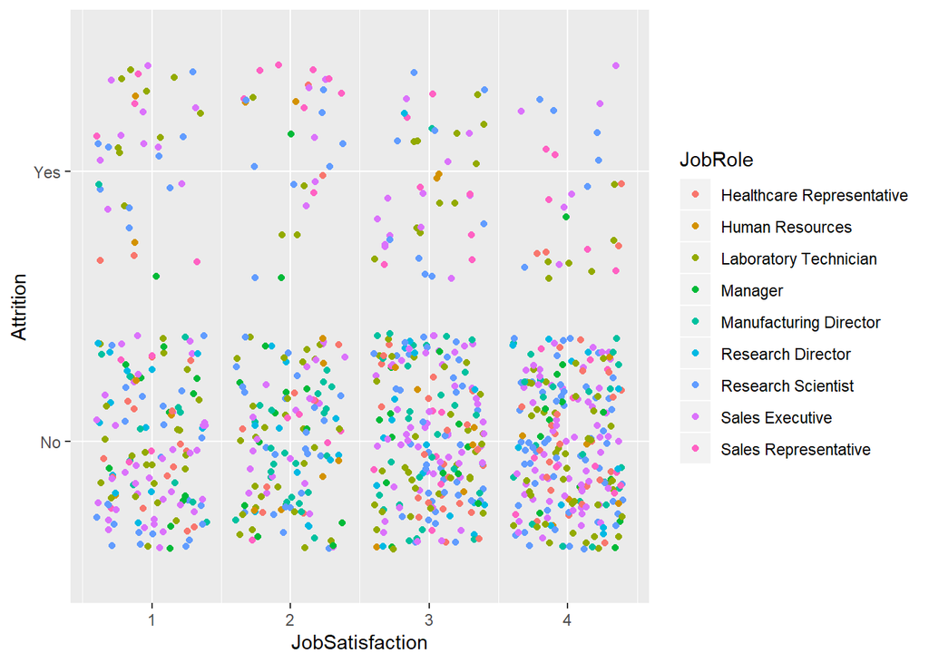

```r
ggplot(work, aes(x=JobSatisfaction, y=Attrition,color=JobRole))+geom_point(position="jitter")
```

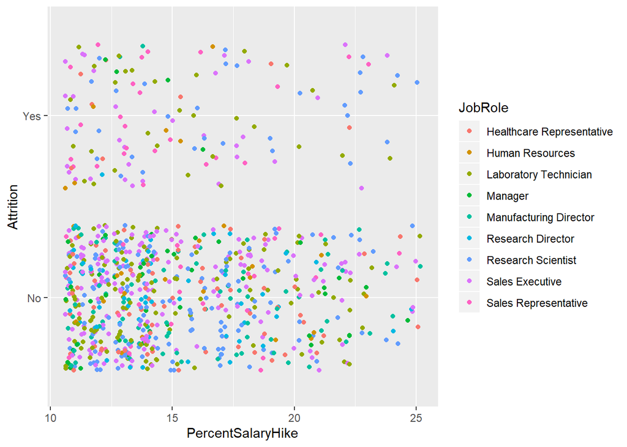

```r
ggplot(work, aes(x=PercentSalaryHike, y=Attrition,color=JobRole))+geom_point(position="jitter")
```

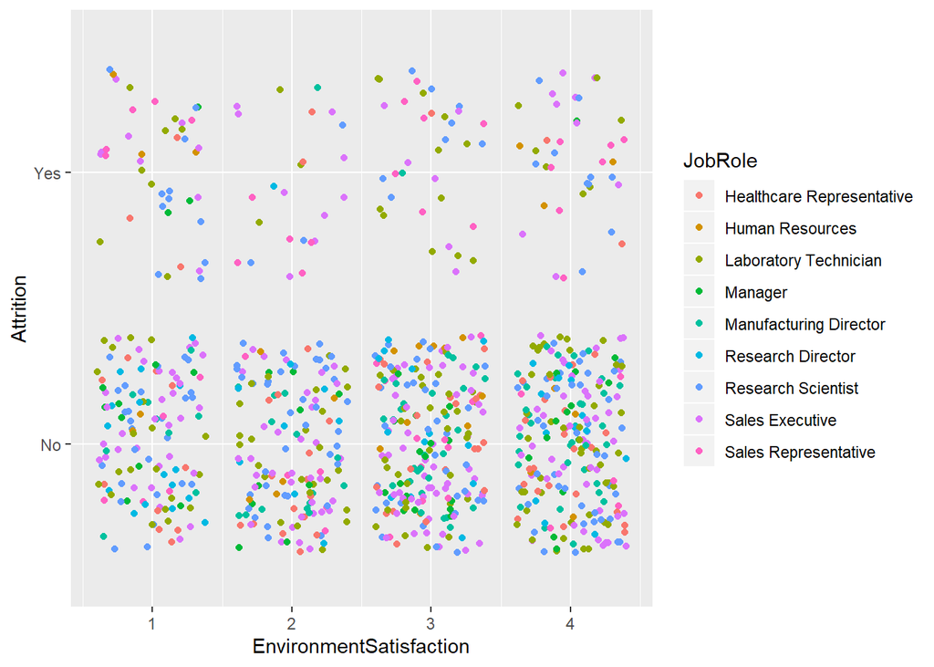

```r
ggplot(work, aes(x=EnvironmentSatisfaction, y=Attrition,color=JobRole))+geom_point(position="jitter")
```

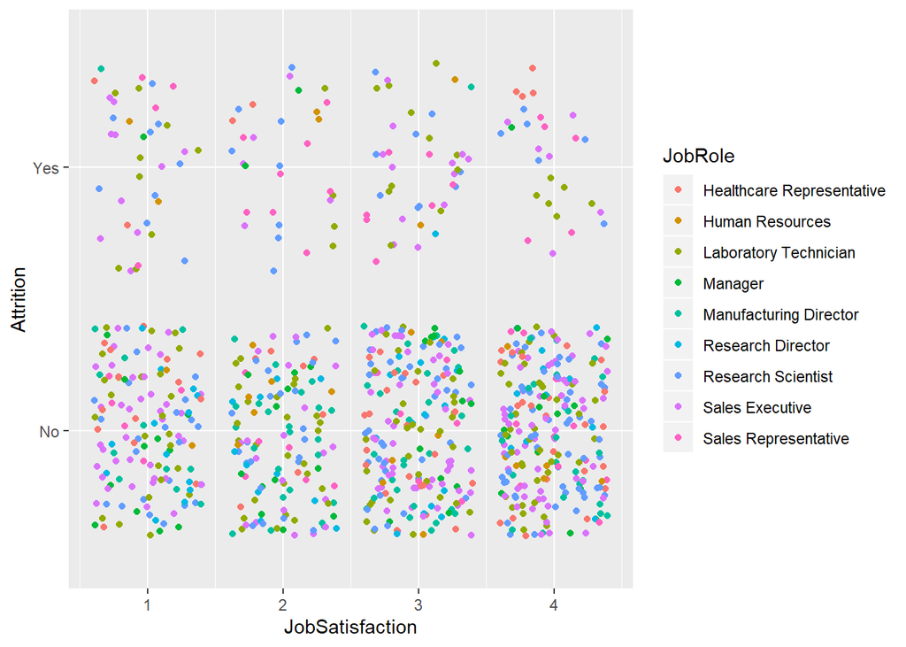

```r
ggplot(work, aes(x=JobSatisfaction, y=Attrition,color=JobRole))+geom_point(position="jitter")
```

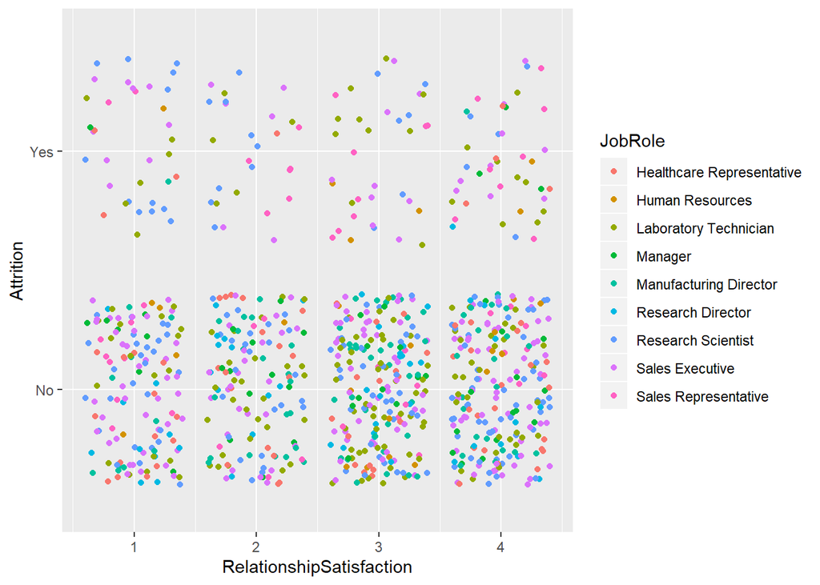

```r
ggplot(work, aes(x=RelationshipSatisfaction, y=Attrition,color=JobRole))+geom_point(position="jitter")
```

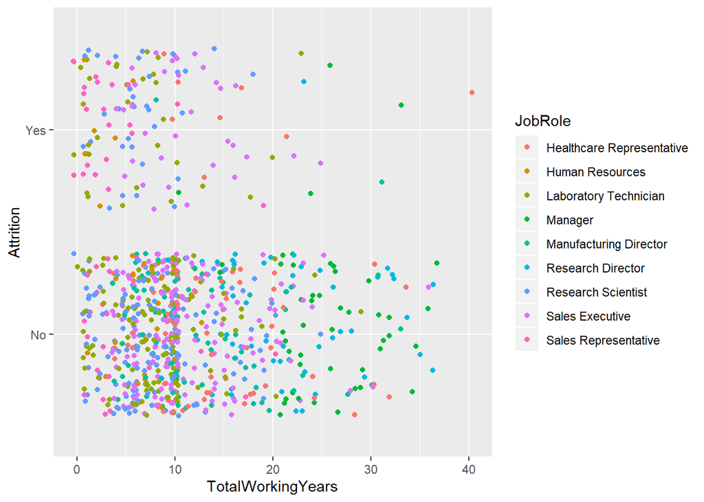

```r
ggplot(work, aes(x=TotalWorkingYears, y=Attrition,color=JobRole))+geom_point(position="jitter")
```

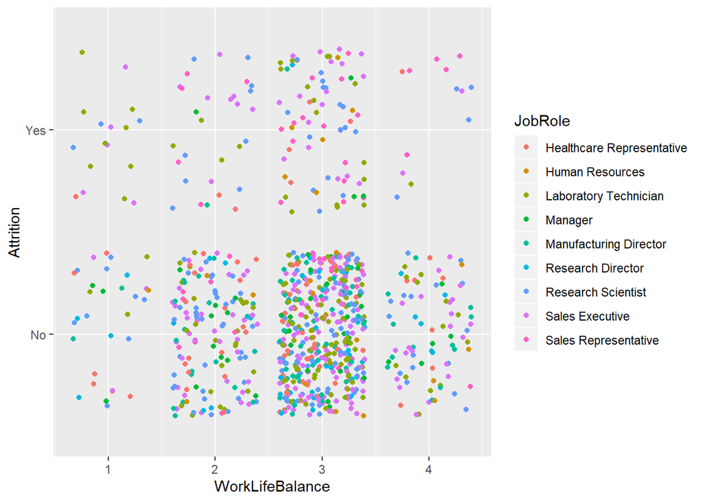

```r
ggplot(work, aes(x=WorkLifeBalance, y=Attrition,color=JobRole))+geom_point(position="jitter")
```

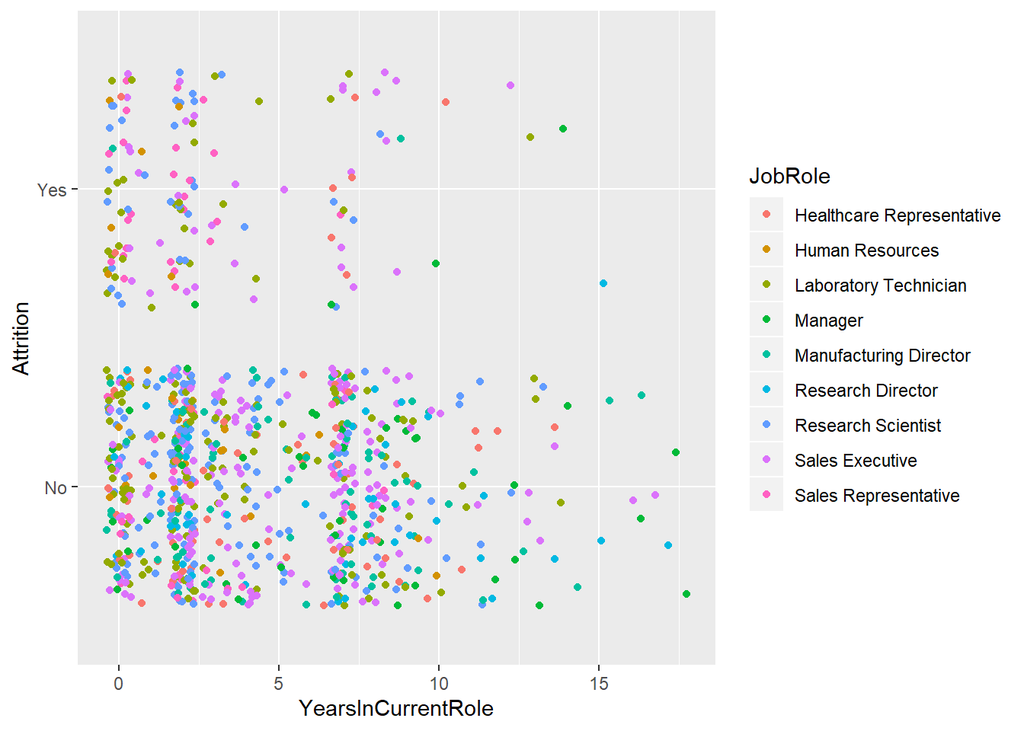

```r
ggplot(work, aes(x=YearsInCurrentRole, y=Attrition,color=JobRole))+geom_point(position="jitter")
```

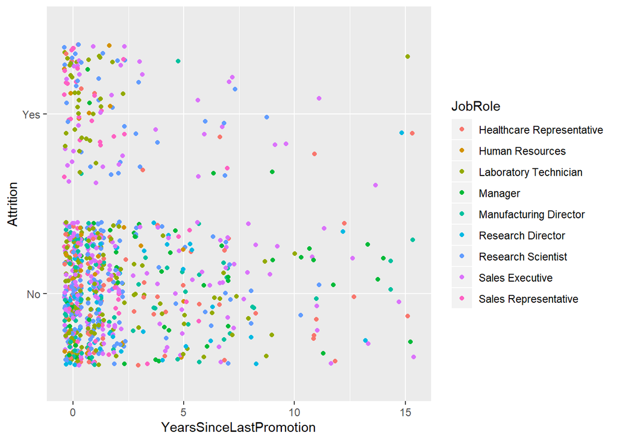

```r
ggplot(work, aes(x=YearsSinceLastPromotion, y=Attrition,color=JobRole))+geom_point(position="jitter")
```

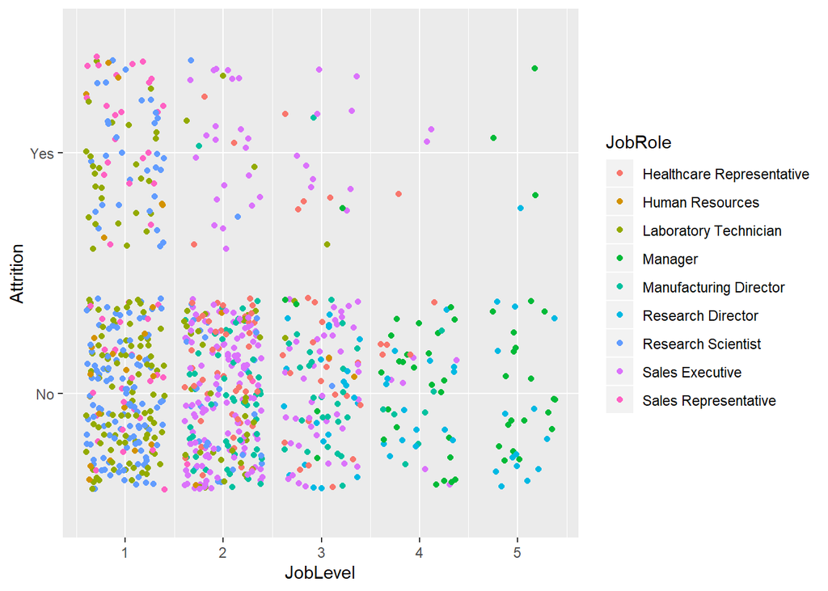

```r
ggplot(work, aes(x=JobLevel, y=Attrition,color=JobRole))+geom_point(position="jitter")
```

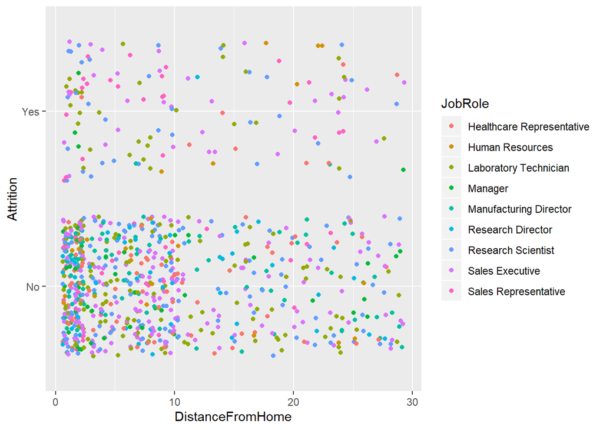

```r
ggplot(work, aes(x=DistanceFromHome, y=Attrition,color=JobRole))+geom_point(position="jitter")
```

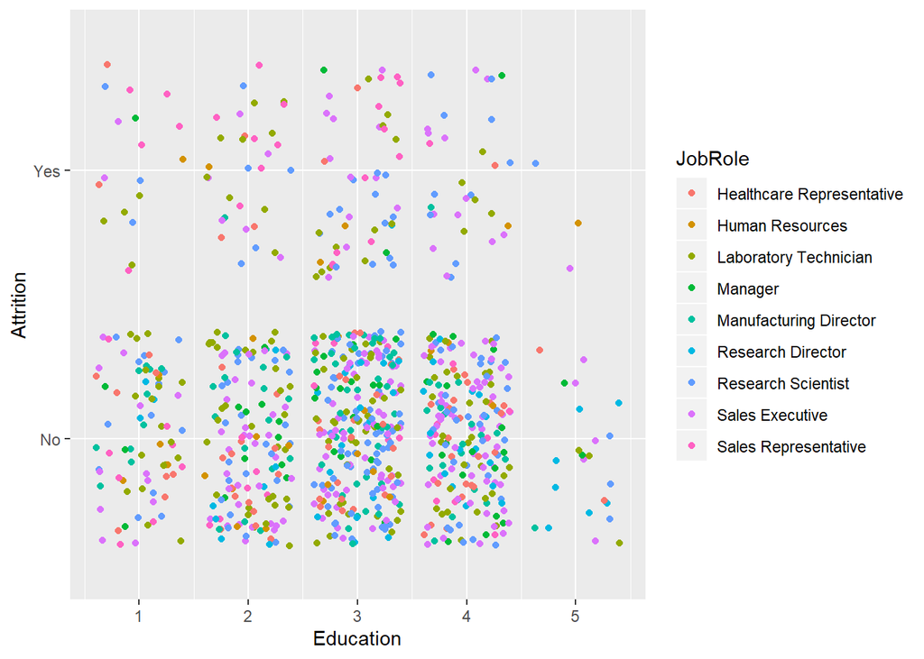

```r
ggplot(work, aes(x=Education, y=Attrition,color=JobRole))+geom_point(position="jitter")
```

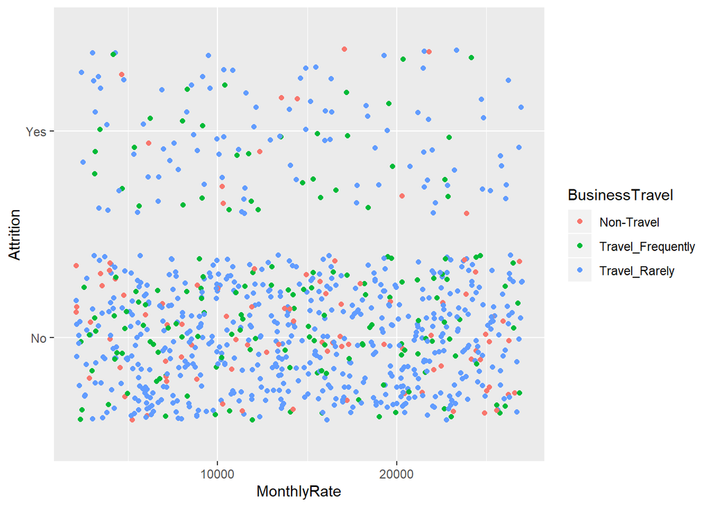

```r
#Checking if Travel Rate has an impact
ggplot(work, aes(x=MonthlyRate, y=Attrition,color=BusinessTravel))+geom_point(position="jitter")
```

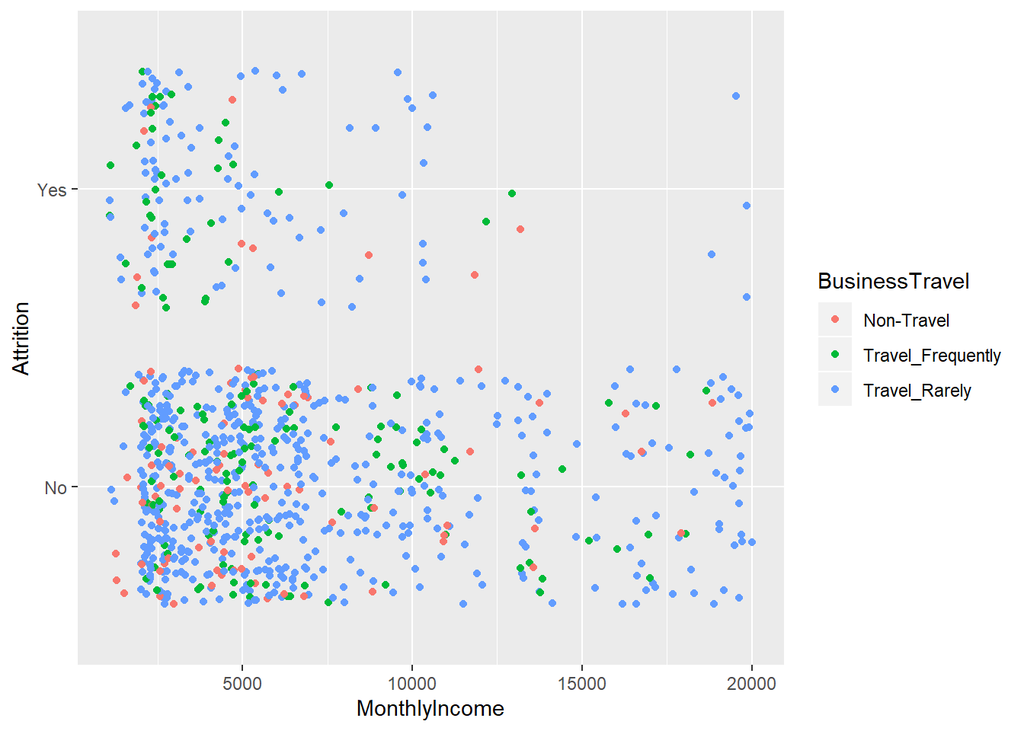

```r
ggplot(work, aes(x=MonthlyIncome, y=Attrition,color=BusinessTravel))+geom_point(position="jitter")
```

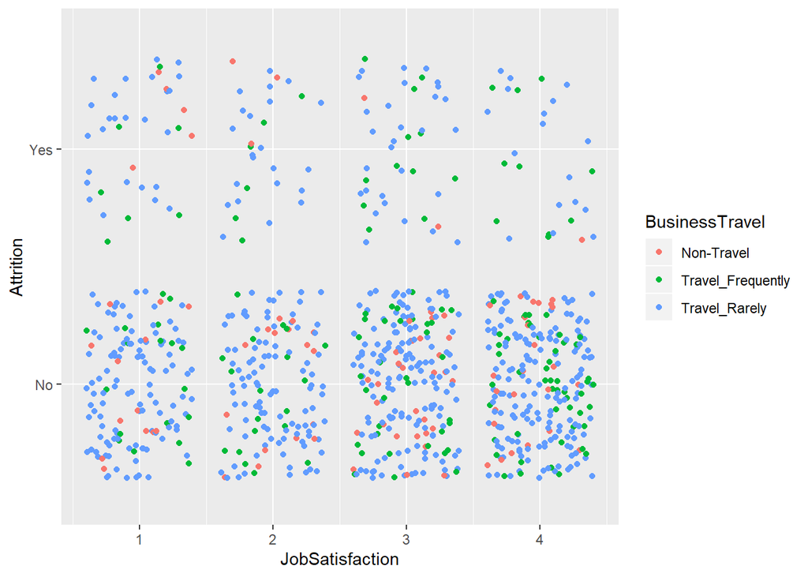

```r
ggplot(work, aes(x=JobSatisfaction, y=Attrition,color=BusinessTravel))+geom_point(position="jitter")
```

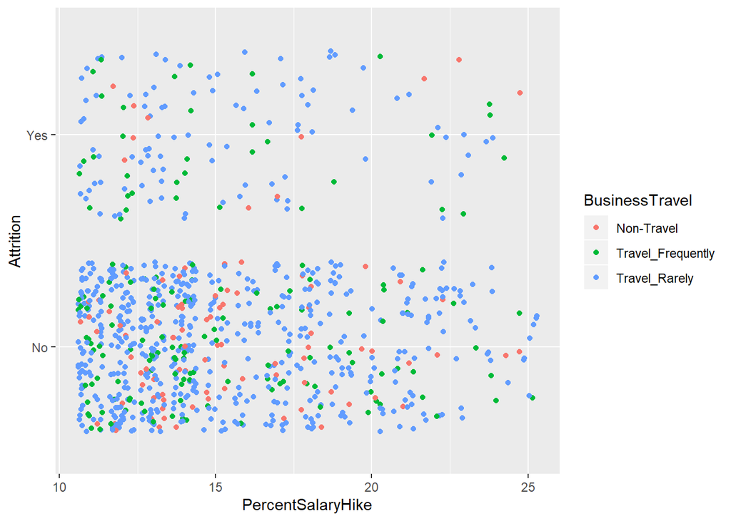

```r
ggplot(work, aes(x=PercentSalaryHike, y=Attrition,color=BusinessTravel))+geom_point(position="jitter")
```

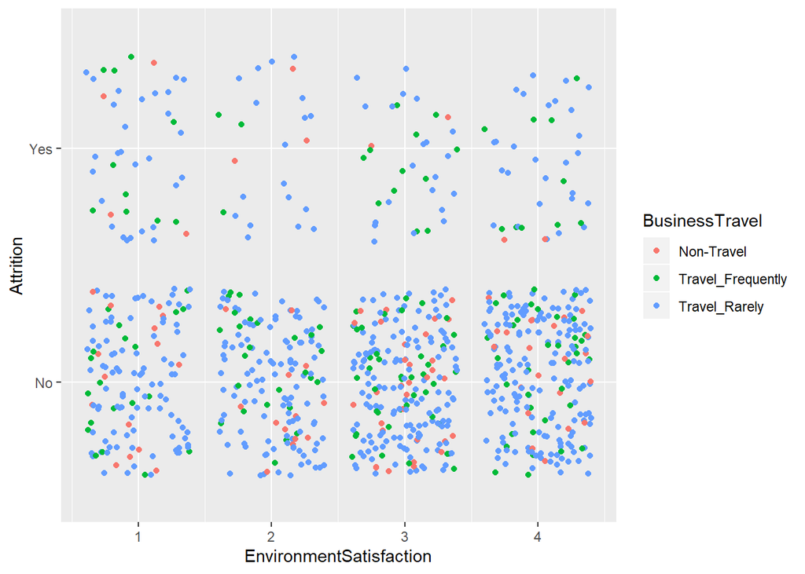

```r
ggplot(work, aes(x=EnvironmentSatisfaction, y=Attrition,color=BusinessTravel))+geom_point(position="jitter")
```

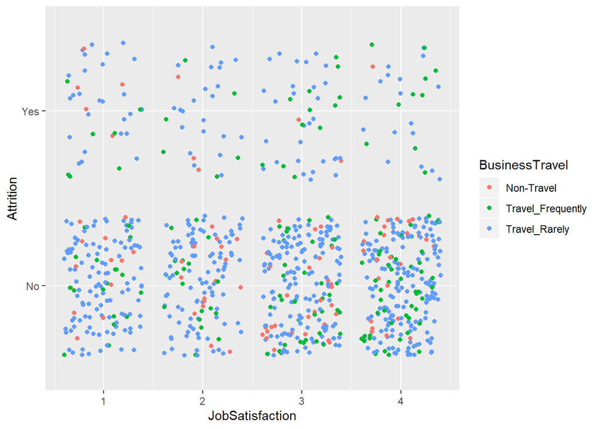

```r
ggplot(work, aes(x=JobSatisfaction, y=Attrition,color=BusinessTravel))+geom_point(position="jitter")
```

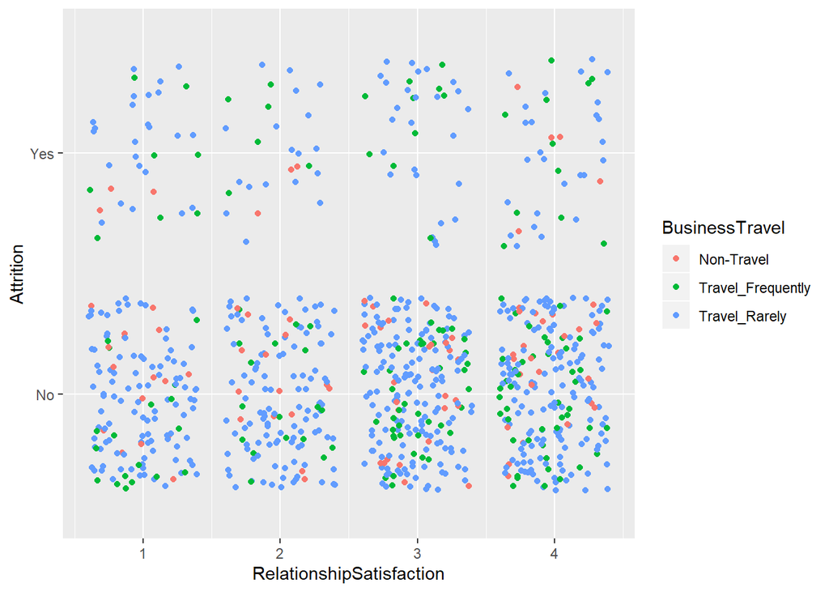

```r
ggplot(work, aes(x=RelationshipSatisfaction, y=Attrition,color=BusinessTravel))+geom_point(position="jitter")
```

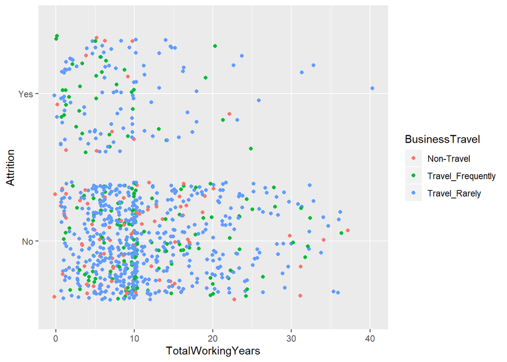

```r
ggplot(work, aes(x=TotalWorkingYears, y=Attrition,color=BusinessTravel))+geom_point(position="jitter")
```

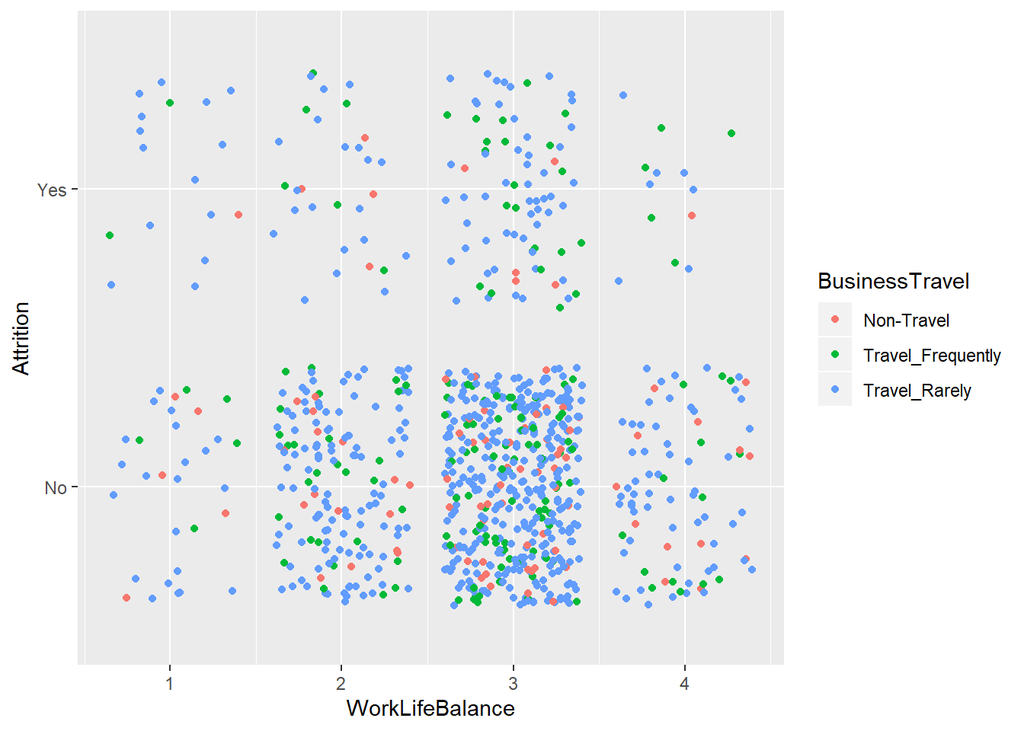

```r
ggplot(work, aes(x=WorkLifeBalance, y=Attrition,color=BusinessTravel))+geom_point(position="jitter")
```

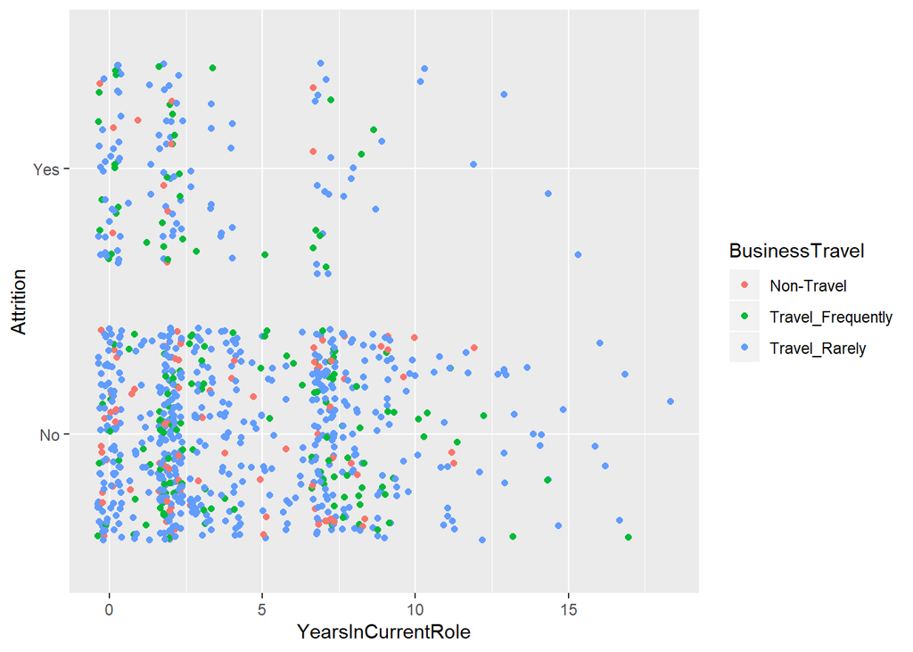

```r
ggplot(work, aes(x=YearsInCurrentRole, y=Attrition,color=BusinessTravel))+geom_point(position="jitter")
```